# 6306 Case Study 2 -

Andrew Walch, Christopher Morgan, Luke Pierce, Eduardo Cantu Medellin

April 7, 2018

## Exploratory Data Analysis

A summary done on the data main data yields that some of the fields may not be needed: EmployeeCount: This shows 1 for all of them EmployeeNumber: This has to do with a random number Over18: All of them are over 18 StandardHours: All records show 80 hours a week.

Luke

```r
library(data.table)
library(readxl)
library(doBy)
library(plyr)
library(dplyr)
```

```r
library(ggplot2)
library(scales)
library(RColorBrewer)
library(colorRamps)
library(readxl)
library(pROC)
library(randomForest)
library(reshape2)
library(forcats)
library(caret)
#library(lattice)
#library(sm)
# Load Data
df <- read.csv("CaseStudy2data.csv")
dfCat <- df[,names(base::Filter(is.factor,df))]
dfCon <- df[,c("Attrition",names(base::Filter(is.integer,df)))]
#head(dfCat)
summary(df) # Check if its posible to format this table in the Rmarkdown
```

```
##       Age        Attrition            BusinessTravel   DailyRate
##  Min.   :18.00   No :1233   Non-Travel       : 150   Min.   : 102.0
##  1st Qu.:30.00   Yes: 237   Travel_Frequently: 277   1st Qu.: 465.0
##  Median :36.00              Travel_Rarely    :1043   Median : 802.0
##  Mean   :36.92                                       Mean   : 802.5
##  3rd Qu.:43.00                                       3rd Qu.:1157.0
##  Max.   :60.00                                       Max.   :1499.0
##
##                   Department  DistanceFromHome   Education
##  Human Resources       : 63   Min.   : 1.000   Min.   :1.000
##  Research & Development:961   1st Qu.: 2.000   1st Qu.:2.000
##  Sales                 :446   Median : 7.000   Median :3.000
##                               Mean   : 9.193   Mean   :2.913
##                               3rd Qu.:14.000   3rd Qu.:4.000
##                               Max.   :29.000   Max.   :5.000
##
##           EducationField EmployeeCount EmployeeNumber
##  Human Resources : 27    Min.   :1     Min.   :   1.0
##  Life Sciences   :606    1st Qu.:1     1st Qu.: 491.2
##  Marketing       :159    Median :1     Median :1020.5
##  Medical         :464    Mean   :1     Mean   :1024.9
##  Other           : 82    3rd Qu.:1     3rd Qu.:1555.8
##  Technical Degree:132    Max.   :1     Max.   :2068.0
##
##  EnvironmentSatisfaction    Gender      HourlyRate     JobInvolvement
##  Min.   :1.000           Female:588   Min.   : 30.00   Min.   :1.00
##  1st Qu.:2.000           Male  :882   1st Qu.: 48.00   1st Qu.:2.00
##  Median :3.000                        Median : 66.00   Median :3.00
##  Mean   :2.722                        Mean   : 65.89   Mean   :2.73
##  3rd Qu.:4.000                        3rd Qu.: 83.75   3rd Qu.:3.00
##  Max.   :4.000                        Max.   :100.00   Max.   :4.00
##
##     JobLevel                          JobRole    JobSatisfaction
##  Min.   :1.000   Sales Executive          :326   Min.   :1.000
##  1st Qu.:1.000   Research Scientist       :292   1st Qu.:2.000
##  Median :2.000   Laboratory Technician    :259   Median :3.000
##  Mean   :2.064   Manufacturing Director   :145   Mean   :2.729
##  3rd Qu.:3.000   Healthcare Representative:131   3rd Qu.:4.000
##  Max.   :5.000   Manager                  :102   Max.   :4.000
##                  (Other)                  :215
```

[output cut: 25 more lines]

```
##  Min.   :0.000         Min.   :1.000   Min.   : 0.000   Min.   : 0.000
##  1st Qu.:2.000         1st Qu.:2.000   1st Qu.: 3.000   1st Qu.: 2.000
##  Median :3.000         Median :3.000   Median : 5.000   Median : 3.000
##  Mean   :2.799         Mean   :2.761   Mean   : 7.008   Mean   : 4.229
##  3rd Qu.:3.000         3rd Qu.:3.000   3rd Qu.: 9.000   3rd Qu.: 7.000
##  Max.   :6.000         Max.   :4.000   Max.   :40.000   Max.   :18.000
##
##  YearsSinceLastPromotion YearsWithCurrManager
##  Min.   : 0.000          Min.   : 0.000
##  1st Qu.: 0.000          1st Qu.: 2.000
##  Median : 1.000          Median : 3.000
##  Mean   : 2.188          Mean   : 4.123
##  3rd Qu.: 3.000          3rd Qu.: 7.000
##  Max.   :15.000          Max.   :17.000
##
```

The data shows an inbalance in the number of people that leave the company vs people that stayed in the job. There are 237 samples with attrition ‘Yes’ and 1233 with attrition ‘No’. The data will be down sampled for the Attrition “Yes” to match the level of Attrition “Yes”

Also, the data was scanned for ‘NA’ values. This scanned did not show any ‘NA’ values.

```r
#### Luke Code

#  Clean file name (Edwardo) - cleanAttDf


# Read xlsx file
rawdata <- read_excel("CaseStudy2data.xlsx")
utils::View(rawdata)
str(rawdata)
```

```
## Classes 'tbl_df', 'tbl' and 'data.frame':    1470 obs. of  35 variables:
##  $ Age                     : num  41 49 37 33 27 32 59 30 38 36 ...
##  $ Attrition               : chr  "Yes" "No" "Yes" "No" ...
##  $ BusinessTravel          : chr  "Travel_Rarely" "Travel_Frequently" "Travel_Rarely" "Travel_Frequently" ...
##  $ DailyRate               : num  1102 279 1373 1392 591 ...
##  $ Department              : chr  "Sales" "Research & Development" "Research & Development" "Research & Development" ...
##  $ DistanceFromHome        : num  1 8 2 3 2 2 3 24 23 27 ...
##  $ Education               : num  2 1 2 4 1 2 3 1 3 3 ...
##  $ EducationField          : chr  "Life Sciences" "Life Sciences" "Other" "Life Sciences" ...
##  $ EmployeeCount           : num  1 1 1 1 1 1 1 1 1 1 ...
##  $ EmployeeNumber          : num  1 2 4 5 7 8 10 11 12 13 ...
##  $ EnvironmentSatisfaction : num  2 3 4 4 1 4 3 4 4 3 ...
##  $ Gender                  : chr  "Female" "Male" "Male" "Female" ...
##  $ HourlyRate              : num  94 61 92 56 40 79 81 67 44 94 ...
##  $ JobInvolvement          : num  3 2 2 3 3 3 4 3 2 3 ...
```

[output cut: 21 more lines]

```r
# Data cleaning for Analysis

# NA per Field
NACount <- sapply(rawdata,function(x) sum(is.na(x)))
NACount <- as.data.frame(NACount)
colnames(NACount)=c("CountOfNAs")
NACount
```

|  | CountOfNAs |
| --- | --- |
| Age | 0 |
| Attrition | 0 |
| BusinessTravel | 0 |
| DailyRate | 0 |
| Department | 0 |
| DistanceFromHome | 0 |
| Education | 0 |
| EducationField | 0 |
| EmployeeCount | 0 |
| EmployeeNumber | 0 |

[output cut: 25 more lines]

```r
#remove reduntant fields
# 9 - Employee Count
# 10 - Employee Number
# 22 - Over18
# 27 - Standard Hours

rawdata <- rawdata[,c(-9,-10,-22,-27)]
colnames(rawdata)
```

```
##  [1] "Age"                      "Attrition"
##  [3] "BusinessTravel"           "DailyRate"
##  [5] "Department"               "DistanceFromHome"
##  [7] "Education"                "EducationField"
##  [9] "EnvironmentSatisfaction"  "Gender"
## [11] "HourlyRate"               "JobInvolvement"
## [13] "JobLevel"                 "JobRole"
## [15] "JobSatisfaction"          "MaritalStatus"
## [17] "MonthlyIncome"            "MonthlyRate"
## [19] "NumCompaniesWorked"       "OverTime"
## [21] "PercentSalaryHike"        "PerformanceRating"
## [23] "RelationshipSatisfaction" "StockOptionLevel"
## [25] "TotalWorkingYears"        "TrainingTimesLastYear"
## [27] "WorkLifeBalance"          "YearsAtCompany"
## [29] "YearsInCurrentRole"       "YearsSinceLastPromotion"
## [31] "YearsWithCurrManager"
```

```r
# Convert numeric categorical variables to character
rawdata$Education <- mapvalues(rawdata$Education, from=c(1, 2, 3, 4, 5), to=c('Below College', 'College', 'Bachelor', 'Master', 'Doctor'))
rawdata$EnvironmentSatisfaction <- mapvalues(rawdata$EnvironmentSatisfaction, from=c(1, 2, 3, 4), to=c('Low', 'Medium', 'High', 'Very High'))
rawdata$JobInvolvement <- mapvalues(rawdata$JobInvolvement, from=c(1, 2, 3, 4), to=c('Low', 'Medium', 'High', 'Very High'))
rawdata$JobSatisfaction <- mapvalues(rawdata$JobSatisfaction, from=c(1, 2, 3, 4), to=c('Low', 'Medium', 'High', 'Very High'))
rawdata$PerformanceRating <- mapvalues(rawdata$PerformanceRating, from=c(3, 4), to=c('Excellent', 'Outstanding'))
rawdata$RelationshipSatisfaction <- mapvalues(rawdata$RelationshipSatisfaction, from=c(1, 2, 3, 4), to=c('Low', 'Medium', 'High', 'Very High'))
rawdata$WorkLifeBalance <- mapvalues(rawdata$WorkLifeBalance, from=c(1, 2, 3, 4), to=c('Bad', 'Good', 'Better', 'Best'))

# Convert character data to factor data
rawdata$Attrition <- as.factor(rawdata$Attrition)
rawdata$BusinessTravel <- as.factor(rawdata$BusinessTravel)
rawdata$Department <- as.factor(rawdata$Department)
rawdata$Education <- as.factor(rawdata$Education)
rawdata$EducationField <- as.factor(rawdata$EducationField)
rawdata$EnvironmentSatisfaction <- as.factor(rawdata$EnvironmentSatisfaction)
rawdata$JobInvolvement <- as.factor(rawdata$JobInvolvement)
rawdata$Gender <- as.factor(rawdata$Gender)
rawdata$JobRole <- as.factor(rawdata$JobRole)
rawdata$JobSatisfaction <- as.factor(rawdata$JobSatisfaction)
rawdata$MaritalStatus <- as.factor(rawdata$MaritalStatus)
rawdata$OverTime <- as.factor(rawdata$OverTime)
rawdata$PerformanceRating <- as.factor(rawdata$PerformanceRating)
rawdata$RelationshipSatisfaction <- as.factor(rawdata$RelationshipSatisfaction)
rawdata$WorkLifeBalance <- as.factor(rawdata$WorkLifeBalance)

cleanAttDf <- rawdata
header <- colnames(cleanAttDf, do.NULL = TRUE, prefix = "col")
utils::View(header)

# Exploratory Analysis ======================================================================================================



AttritionTable <- table(cleanAttDf$Attrition)
PT <- prop.table(AttritionTable)
PT
```

```
##
##        No       Yes
## 0.8387755 0.1612245
```

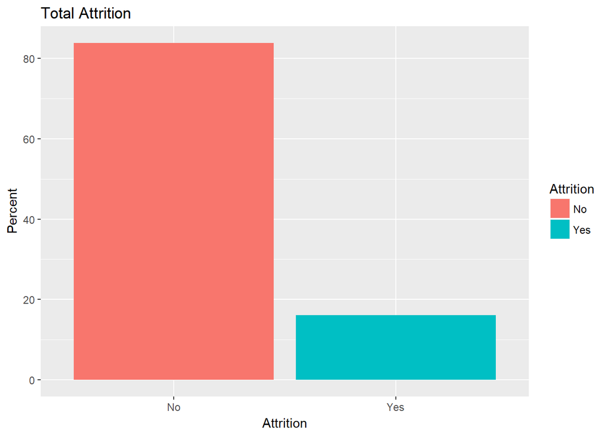

```r
# ggplot Bar Plot (percentage)
g <- ggplot(cleanAttDf, aes(x = Attrition)) + geom_bar(aes(fill=Attrition, y=100*(..count..)/sum(..count..)))
AttritionBCP <- g + xlab("Attrition") + ylab("Percent") + ggtitle("Total Attrition")
AttritionBCP
```

```r
## Attrition rate: 16%

# ===Age=====================================================================================================================================================

## Subset Age by 5, categorical vector
# 18-22,23-27,28-32,33-37,38-42,43-47,48-52,53+
cleanAttDf$Ageby5 <- findInterval(cleanAttDf$Age, c(18, 23, 28, 33, 38, 43, 48, 53))
cleanAttDf$Ageby5 <- mapvalues(cleanAttDf$Ageby5, from=c(1, 2, 3, 4, 5, 6, 7, 8), to=c('18-22', '23-27', '28-32', '33-37', '38-42', '43-47','48-52','53+'))
cleanAttDf$Ageby5 <- as.factor(cleanAttDf$Ageby5)

# Generate property summary for variable
AgeTable <- table(cleanAttDf$Ageby5, cleanAttDf$Attrition)
PT <- prop.table(AgeTable)
PTdf <- as.data.frame(PT)
colnames(PTdf)[c(1,2)] <- c("Age" , "Attrition" )
PT
```

```
##
##                  No         Yes
##   18-22 0.020408163 0.018367347
##   23-27 0.082312925 0.021768707
##   28-32 0.160544218 0.047619048
##   33-37 0.196598639 0.029251701
##   38-42 0.151020408 0.014285714
##   43-47 0.099319728 0.011564626
##   48-52 0.065306122 0.009523810
##   53+   0.063265306 0.008843537
```

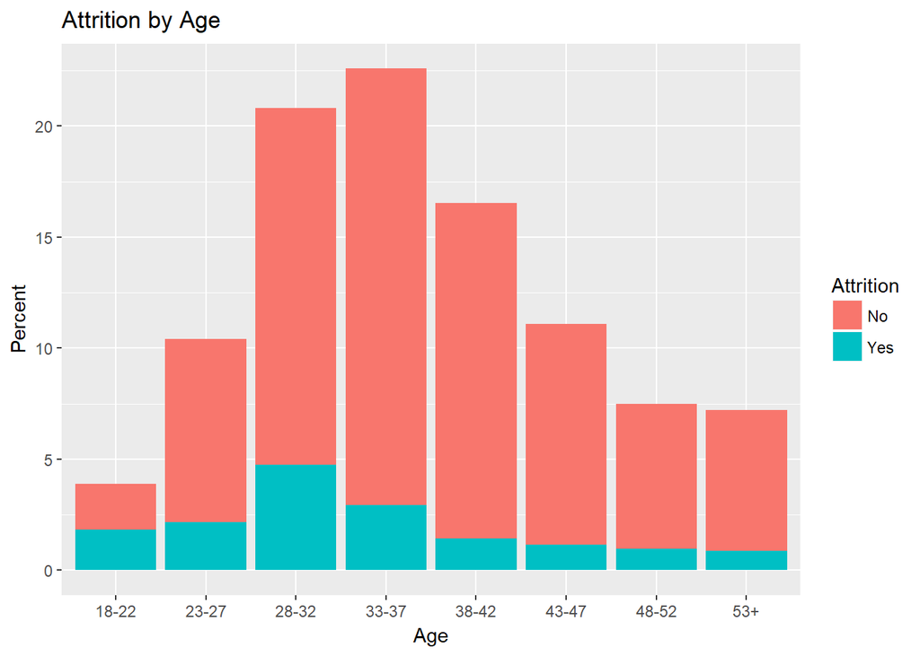

```r
# Plot Age Range vs, Percent Attrition
g <- ggplot(PTdf, aes(x = Age, y = (100*Freq), fill=Attrition)) + geom_bar(stat = "identity")
AgeBP <- g + xlab("Age") + ylab("Percent") + ggtitle("Attrition by Age")
AgeBP
```

```r
## Notes
# 47% Attrition in the 18-23 age bracket

# ===Business Travel=====================================================================================================================================================

# Generate property summary for variable
BusinessTravelTable <- table(cleanAttDf$BusinessTravel, cleanAttDf$Attrition)
PT <- prop.table(BusinessTravelTable)
PTdf <- as.data.frame(PT)
#PTdf <- rename(PTdf, c("Var1"="BusinessTravel","Var2" = "Attrition" ))  #### Knit Does not like this
colnames(PTdf)[c(1,2)] <- c("BusinessTravel","Attrition" )
PT
```

```
##
##                              No         Yes
##   Non-Travel        0.093877551 0.008163265
##   Travel_Frequently 0.141496599 0.046938776
##   Travel_Rarely     0.603401361 0.106122449
```

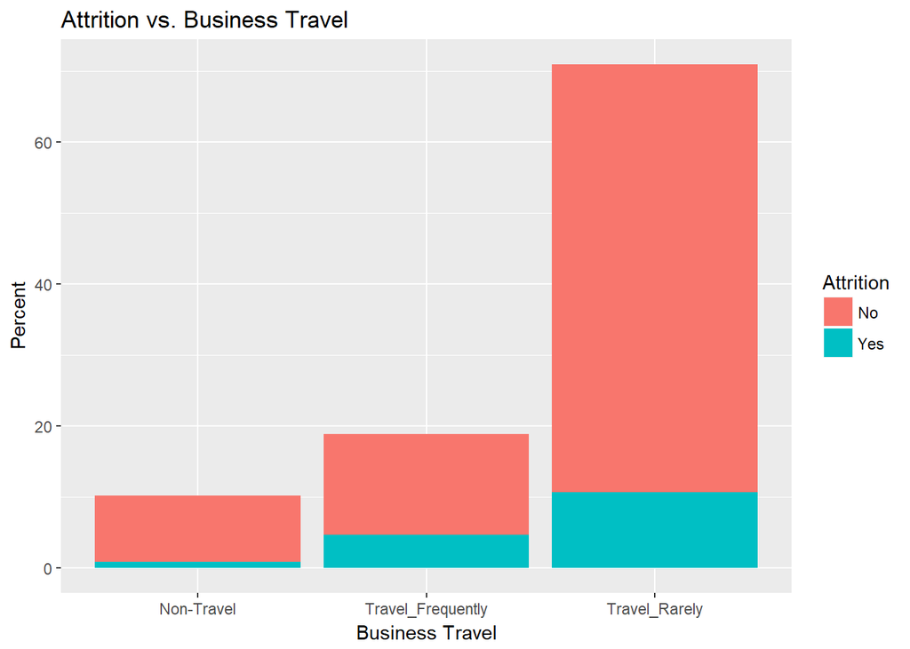

```r
# Plot Marital Status vs, Attrition Percent
g <- ggplot(PTdf, aes(x = fct_reorder(BusinessTravel, Freq), y = (100*Freq), fill=Attrition)) + geom_bar(stat = "identity")
BusinessTravelBP <- g + xlab("Business Travel") + ylab("Percent") + ggtitle("Attrition vs. Business Travel")
BusinessTravelBP
```

```r
## Notes
# Minimal Factor

### Luke Code End



#remove reduntant fields


cleanAttDf <- df[,c(-9,-10,-22,-27)]
colnames(cleanAttDf)
```

```
##  [1] "Age"                      "Attrition"
##  [3] "BusinessTravel"           "DailyRate"
##  [5] "Department"               "DistanceFromHome"
##  [7] "Education"                "EducationField"
##  [9] "EnvironmentSatisfaction"  "Gender"
## [11] "HourlyRate"               "JobInvolvement"
## [13] "JobLevel"                 "JobRole"
## [15] "JobSatisfaction"          "MaritalStatus"
## [17] "MonthlyIncome"            "MonthlyRate"
## [19] "NumCompaniesWorked"       "OverTime"
## [21] "PercentSalaryHike"        "PerformanceRating"
## [23] "RelationshipSatisfaction" "StockOptionLevel"
## [25] "TotalWorkingYears"        "TrainingTimesLastYear"
## [27] "WorkLifeBalance"          "YearsAtCompany"
## [29] "YearsInCurrentRole"       "YearsSinceLastPromotion"
## [31] "YearsWithCurrManager"
```

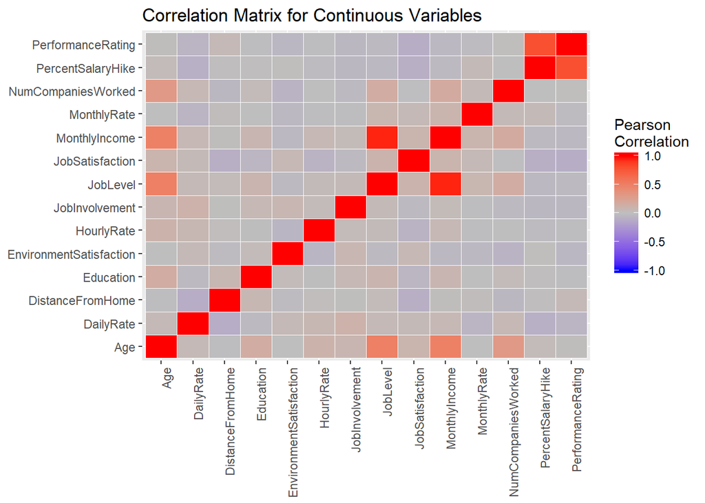

```r
# change variables as factors
# cleanAttDf$JobLevel <- as.factor(cleanAttDf$JobLevel)
# cleanAttDf$JobInvolvement <- as.factor(cleanAttDf$JobInvolvement)
# cleanAttDf$EnvironmentSatisfaction <- as.factor(cleanAttDf$EnvironmentSatisfaction)
# cleanAttDf$Education <- as.factor(cleanAttDf$Education)
# cleanAttDf$JobSatisfaction <- as.factor(cleanAttDf$JobSatisfaction)
# cleanAttDf$RelationshipSatisfaction <- as.factor(cleanAttDf$RelationshipSatisfaction)
# cleanAttDf$StockOptionLevel <- as.factor(cleanAttDf$StockOptionLevel)
# cleanAttDf$PerformanceRating <- as.factor(cleanAttDf$PerformanceRating)
# cleanAttDf$WorkLifeBalance <- as.factor(cleanAttDf$WorkLifeBalance)



# Downsample the 'Yes' Attrition
set.seed(15)
cleanAttDfDs <- downSample(x=cleanAttDf, y=cleanAttDf$Attrition)

cleanAttDfDs_cat <- cleanAttDfDs[,names(base::Filter(is.factor,cleanAttDfDs))]
cleanAttDfDs_con <- cleanAttDfDs[,c("Attrition",names(base::Filter(is.integer,cleanAttDfDs)))]

cleanAttDfDs_conCorr <- cor(cleanAttDfDs_con[,2:15])

# Correlation heatmap
ggplot(data=melt(cleanAttDfDs_conCorr), aes(x=Var1,y=Var2,fill=value)) + geom_tile(color="white") +
  theme(axis.text.x = element_text(angle=90, hjust = 1)) +
  scale_fill_gradient2(low="blue",high="Red",mid="grey" ,
                       midpoint = 0, limit=c(-1,1), space = "Lab",
                       name="Pearson \nCorrelation") +
  ggtitle("Correlation Matrix for Continuous Variables") +
  theme(
    axis.title.x = element_blank(),
    axis.title.y = element_blank()
  )
```

```r
#splom(cleanAttDfDs_con[,2:15], groups=cleanAttDfDs_con$Attrition, data=cleanAttDfDs_con, panel=panel.superpose)

#pairs(cleanAttDfDs_con[,2:15],col=cleanAttDfDs_con$Attrition)

#histograms for data
# barPlot1 <- ggplot(data = melt(cleanAttDfDs_cat[,1:6], id=c("Attrition")), mapping= aes(x=value, fill=Attrition) ) +
#   geom_histogram(stat="count")  +
#   facet_grid(Attrition~variable, scales = "free")+ theme(axis.text.x = element_text(angle=90, hjust = 1)) + xlab("Categories")
#
# barPlot2 <- ggplot(data = melt(cleanAttDfDs_cat[,c(1,7:11)], id=c("Attrition")), mapping= aes(x=value, fill=Attrition) ) +
#   geom_histogram(stat="count")  +
#   facet_grid(Attrition~variable, scales = "free")+ theme(axis.text.x = element_text(angle=90, hjust = 1)) + xlab("Categories")
#
#
# barPlot3 <-  ggplot(data = melt(cleanAttDfDs_cat[,c(1,12:17)], id=c("Attrition")), mapping= aes(x=value, fill=Attrition) ) +
#   geom_histogram(stat="count")  +
#   facet_grid(Attrition~variable, scales = "free")+ theme(axis.text.x = element_text(angle=90, hjust = 1)) + xlab("Categories")
#
# barPlot1
# barPlot2
# barPlot3
```

### Problem

DDS Analytics specializes in talent management solutions for Fortune 1000 companies. This company has provided a dataset (CaseStudy2Data.zip) and would like to identify the factors that lead to attrition. The company is interested to know what are the Top three factors that contribute to turnover.

### Model - Random Forest

The Top 3 factors that affect attrition would be treated as a classification problem. The Random Forrest algorithm will be used to classify based on the explanatory variables the attrition outcome. The random forest fit model will provide the important factor for the classifying model.

#### Intial Random Forest Fit

As indicated in the EDA, the data is not balanced. On this initial fit of the model, a random downsample will be used to fit the initial classification model.

The initial Random Forest suggests that the Top 3 factors are: * Monthly Income * Age * Jobe Role

```r
#use the clean data set that is down sampled.
#cleanAttDfDs
#ncol(cleanAttDfDs)

# Initial Random Forrest Classifier
clf_1 <- randomForest(cleanAttDfDs[,c(1,3:31)],cleanAttDfDs[,2])
impClf_1<- clf_1$importance

impFactors <- as.data.frame(sort(impClf_1[,1], decreasing=TRUE))
colnames(impFactors)<- "MeanDecreaseGini"
impFactors
```

|  | MeanDecreaseGini |
| --- | --- |
| JobRole | 18.749652 |
| MonthlyIncome | 17.589748 |
| Age | 13.749269 |
| DailyRate | 12.187754 |
| YearsAtCompany | 11.928317 |
| DistanceFromHome | 11.026760 |
| MonthlyRate | 10.985193 |
| TotalWorkingYears | 10.982409 |
| OverTime | 10.886508 |
| HourlyRate | 9.636137 |

[output cut: 20 more lines]

```r
#barplot(sort(impClf_1[,1]), horiz = "False", col=impClf_1)
```

#### Validation

As a way to validate the initial fit the downsampled data will be randomly split into training and test data. The proportion is 70% Train and 30% Test.

The model using 70% still shows the initial three top factors.

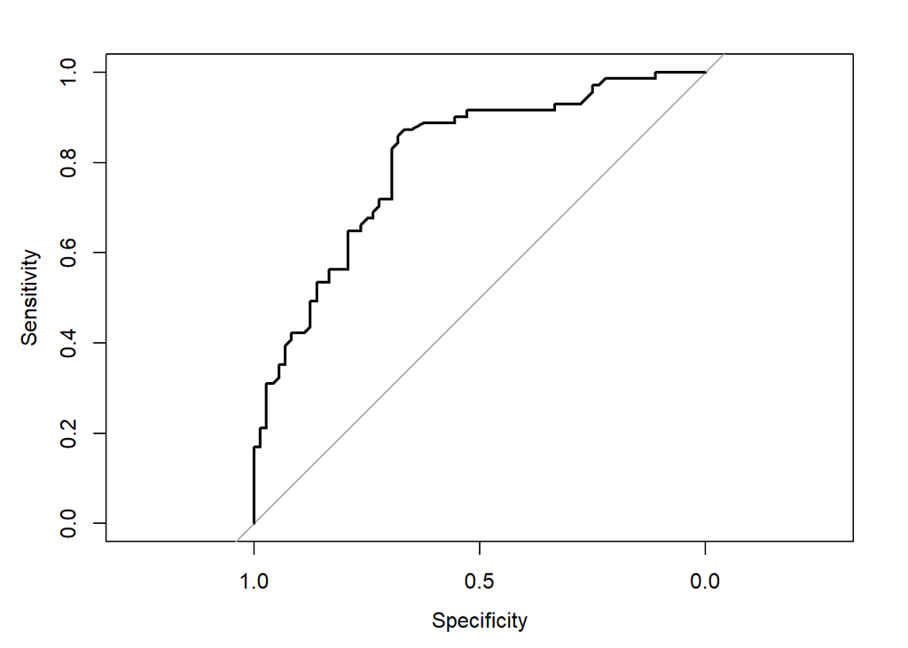

```r
#Test ROC Random Forest
num_obs=nrow(cleanAttDfDs)

train_idx <- sample(c(1:num_obs),size=num_obs*0.7,replace = FALSE)

clf_2 = randomForest(cleanAttDfDs[train_idx,c(1,3:31)],cleanAttDfDs[train_idx,2])
predicAtt <- predict(clf_2,cleanAttDfDs[-train_idx,c(1,3:31)], type="prob" )
plot(roc(cleanAttDfDs[-train_idx,2], as.numeric(predicAtt[,1])))
```

```r
auc.clf2 <- roc(cleanAttDfDs[-train_idx,2], as.numeric(predicAtt[,1]),auc=TRUE)
auc.clf2$auc
```

```
## Area under the curve: 0.8042
```

```r
impClf_2<- clf_2$importance
impFactors2 <- as.data.frame(sort(impClf_2[,1], decreasing=TRUE))
colnames(impFactors2)<- "MeanDecreaseGini"
impFactors2
```

|  | MeanDecreaseGini |
| --- | --- |
| MonthlyIncome | 14.3893063 |
| JobRole | 14.0844283 |
| Age | 9.4607366 |
| YearsAtCompany | 9.0815446 |
| DailyRate | 8.4227741 |
| TotalWorkingYears | 8.2814635 |
| MonthlyRate | 7.9982909 |
| HourlyRate | 6.7642312 |
| DistanceFromHome | 6.3410094 |
| JobLevel | 6.0063708 |

[output cut: 20 more lines]

This section will have two loops for the next level of validation. The outer loop will variate the down sample of the data to understand if by selecting random samples from the Attrition “No” values would the results change. The inner loop will variate the training and test sets. In each iteration, the AUC and Top 3 factors will be captured and then present histograms of the results.

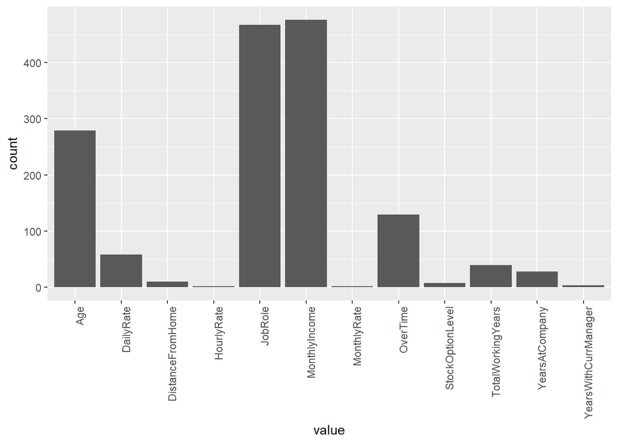

```r
nDsLoop <- 50 # Number of loops of down sample the main dataset
nloops <- 10 # Number of validation loops
cv.aucs <-c() #initializing the area under the curve variable
cv.top3pred <- c() #initializing the histogram for the importance factor
for (d in 1:nDsLoop){ # downsample loop
  cleanAttDfDs <- downSample(x=cleanAttDf, y=cleanAttDf$Attrition)
    for (i in 1:nloops){  # validation loop
      train_idx <- sample(c(1:num_obs),size=num_obs*0.7,replace = FALSE)
      clf_3 = randomForest(cleanAttDfDs[train_idx,c(1,3:31)],cleanAttDfDs[train_idx,2])
      predicAtt <- predict(clf_3,cleanAttDfDs[-train_idx,c(1,3:31)], type="prob" )
      auc.clf3 <- roc(cleanAttDfDs[-train_idx,2], as.numeric(predicAtt[,1]),auc=TRUE)
      #plot(roc(cleanAttDfDs[-train_idx,2], as.numeric(predicAtt[,1])))
      cv.aucs[i]<-as.numeric(auc.clf3$auc)
      Pred_Results <- clf_3$importance
      sortedResults <- as.matrix(Pred_Results[order(Pred_Results[,1], decreasing = "TRUE"),])
      Top3Pred <- rownames(sortedResults)
      cv.top3pred<-rbind(cv.top3pred,Top3Pred[1:3])
    }
}
ggplot(melt(cv.top3pred), mapping = aes(x=value)) + geom_histogram(stat = "count") + theme(axis.text.x = element_text(angle=90, hjust = 1))
```

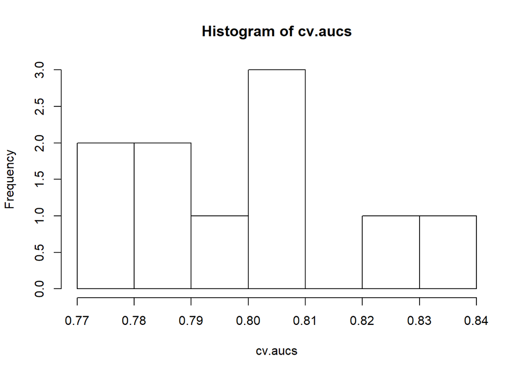

```r
hist(cv.aucs)
```

```r
summary(cv.aucs)
```

```
##    Min. 1st Qu.  Median    Mean 3rd Qu.    Max.
##  0.7776  0.7818  0.7999  0.7999  0.8070  0.8362
```